# week_2_markdown

Tim Fässler

5/4/2022

# Preparation

```r
library(readr)        # to import tabular data (e.g. csv)
library(dplyr)        # to manipulate (tabular) data
library(ggplot2)      # to visualize data
library(sf)           # to handle spatial vector data
library(terra)        # To handle raster data
library(lubridate)    # To handle dates and times
library(zoo)

wildschwein_BE <- read_delim("wildschwein_BE_2056.csv",",")

wildschwein_BE <- st_as_sf(wildschwein_BE, coords = c("E", "N"), crs = 2056, remove = FALSE)
```

# Task 2

```r
wildschwein <- wildschwein_BE %>% group_by(TierName) %>% mutate(timelag = as.integer(difftime(DatetimeUTC, lag(DatetimeUTC), units = "secs" )))

wildschwein %>% group_by(TierName) %>% summarise(mean(timelag, na.rm = TRUE))
```

```
## Simple feature collection with 3 features and 2 fields
## Geometry type: MULTIPOINT
## Dimension:     XY
## Bounding box:  xmin: 2568153 ymin: 1202306 xmax: 2575154 ymax: 1207609
## Projected CRS: CH1903+ / LV95
## # A tibble: 3 x 3
##   TierName `mean(timelag, na.rm = TRUE)`                                geometry
##   <chr>                            <dbl>                        <MULTIPOINT [m]>
## 1 Rosa                             1412. ((2569231 1205823), (2569245 1205925),~
## 2 Ruth                             1599. ((2568153 1205611), (2568155 1205613),~
## 3 Sabi                             1286. ((2568903 1206200), (2568925 1206207),~
```

```r
wildschwein
```

```
## Simple feature collection with 51246 features and 7 fields
## Geometry type: POINT
## Dimension:     XY
## Bounding box:  xmin: 2568153 ymin: 1202306 xmax: 2575154 ymax: 1207609
## Projected CRS: CH1903+ / LV95
## # A tibble: 51,246 x 8
## # Groups:   TierName [3]
##    TierID TierName CollarID DatetimeUTC                E        N
##  * <chr>  <chr>       <dbl> <dttm>                 <dbl>    <dbl>
##  1 002A   Sabi        12275 2014-08-22 21:00:12 2570409. 1204752.
##  2 002A   Sabi        12275 2014-08-22 21:15:16 2570402. 1204863.
##  3 002A   Sabi        12275 2014-08-22 21:30:43 2570394. 1204826.
##  4 002A   Sabi        12275 2014-08-22 21:46:07 2570379. 1204817.
##  5 002A   Sabi        12275 2014-08-22 22:00:22 2570390. 1204818.
##  6 002A   Sabi        12275 2014-08-22 22:15:10 2570390. 1204825.
##  7 002A   Sabi        12275 2014-08-22 22:30:13 2570387. 1204831.
##  8 002A   Sabi        12275 2014-08-22 22:45:11 2570381. 1204840.
##  9 002A   Sabi        12275 2014-08-22 23:00:27 2570316. 1204935.
## 10 002A   Sabi        12275 2014-08-22 23:15:41 2570393. 1204815.
## # ... with 51,236 more rows, and 2 more variables: geometry <POINT [m]>,
## #   timelag <int>
```

```r
summary(wildschwein$timelag)
```

```
##    Min. 1st Qu.  Median    Mean 3rd Qu.    Max.    NA's
##      12     896     903    1408     916   60367       3
```

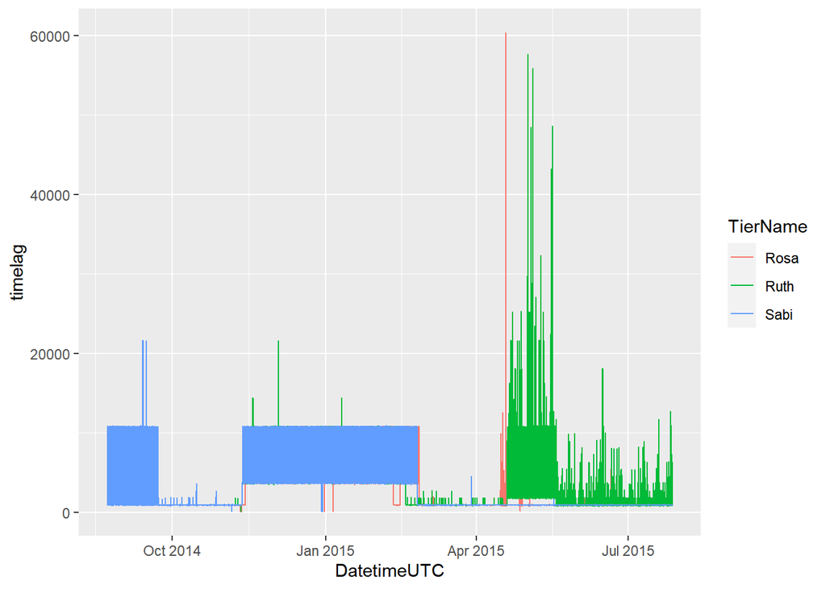

```r
ggplot(wildschwein) +
  geom_line(aes(DatetimeUTC, timelag, color = TierName))
```

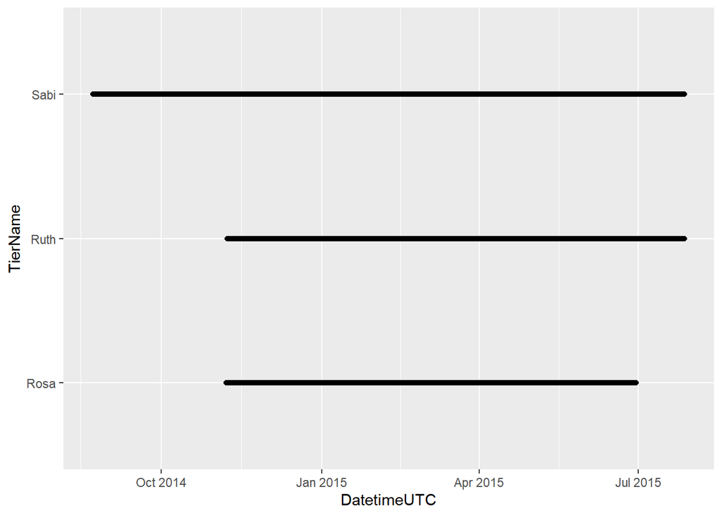

```r
ggplot(wildschwein) +
  geom_point(aes(DatetimeUTC, TierName))
```

Questions:

How many individuals were tracked? -> 3 For how long were the individual tracked? Are there gaps? -> Between about a half a year (Rosa) and about a year(Sabi). Were all individuals tracked concurrently or sequentially? -> Concurrently mostly What is the temporal sampling interval between the locations? -> The means of the timelags vary between ca. 27 min (Ruth) and ca. 21 min (Sabi). there seem to be a few outliers, especially in Ruths case, but the never are longer than ca. 17 hours so it still might not be seen as a too large of a gap.

# Task 3

```r
wildschwein <- wildschwein %>% mutate(steplength = sqrt( ((E - lead(E, 1))^2) + ((N - lead(N, 1))^2) ))

wildschwein <- wildschwein %>% group_by(TierName) %>% mutate(speed = steplength/lead(timelag))

summary(wildschwein$speed)
```

```
##     Min.  1st Qu.   Median     Mean  3rd Qu.     Max.     NA's
## 0.000000 0.004053 0.011061 0.040585 0.033488 1.348674        3
```

```r
wildschwein %>% group_by(TierName) %>% summarise(mean(speed, na.rm = T))
```

```
## Simple feature collection with 3 features and 2 fields
## Geometry type: MULTIPOINT
## Dimension:     XY
## Bounding box:  xmin: 2568153 ymin: 1202306 xmax: 2575154 ymax: 1207609
## Projected CRS: CH1903+ / LV95
## # A tibble: 3 x 3
##   TierName `mean(speed, na.rm = T)`                                     geometry
##   <chr>                       <dbl>                             <MULTIPOINT [m]>
## 1 Rosa                       0.0368 ((2569231 1205823), (2569245 1205925), (256~
## 2 Ruth                       0.0503 ((2568153 1205611), (2568155 1205613), (256~
## 3 Sabi                       0.0369 ((2568903 1206200), (2568925 1206207), (256~
```

Questions: What speed unit do you get? -> The speed is in meter/second but could of course be changed to km/h. The variable (especially means of it or similar) however needs to be used with caution anyway because it sometimes is over a very large timeperiod like the 16+ hours of one timelag measure.

# Task 4

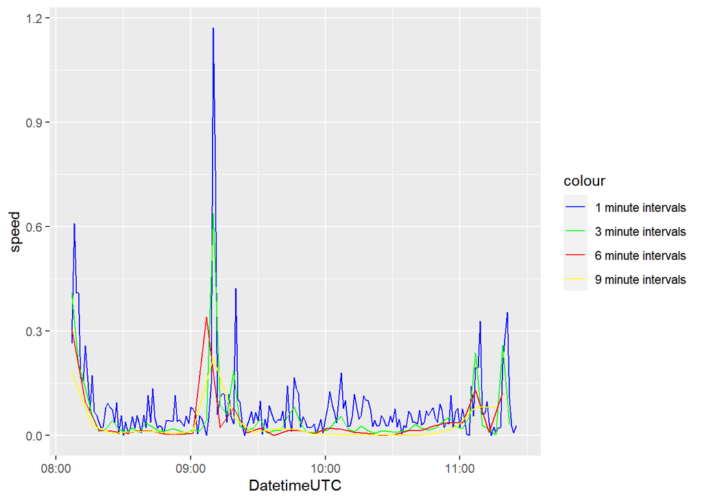

```r
caro <- read_delim("caro60.csv",",")

caro <- st_as_sf(caro, coords = c("E", "N"), crs = 2056, remove = FALSE)

seq3 = seq(1, 200, by = 3)
seq6 = seq(1, 200, by = 6)
seq9 = seq(1, 200, by = 9)

caro_3 = slice(caro, seq3)
caro_6 = slice(caro, seq6)
caro_9 = slice(caro, seq9)

caro <- caro %>% mutate(timelag = as.integer(difftime(DatetimeUTC, lag(DatetimeUTC), units = "secs"))) %>% mutate(steplength = sqrt( ((E - lead(E, 1))^2) + ((N - lead(N, 1))^2) ) ) %>% mutate(speed = steplength/lead(timelag))

caro_3 <- caro_3 %>% mutate(timelag = as.integer(difftime(DatetimeUTC, lag(DatetimeUTC), units = "secs"))) %>% mutate(steplength = sqrt( ((E - lead(E, 1))^2) + ((N - lead(N, 1))^2) ) ) %>% mutate(speed = steplength/lead(timelag))

caro_6 <- caro_6 %>% mutate(timelag = as.integer(difftime(DatetimeUTC, lag(DatetimeUTC), units = "secs"))) %>% mutate(steplength = sqrt( ((E - lead(E, 1))^2) + ((N - lead(N, 1))^2) ) ) %>% mutate(speed = steplength/lead(timelag))

caro_9 <- caro_9 %>% mutate(timelag = as.integer(difftime(DatetimeUTC, lag(DatetimeUTC), units = "secs"))) %>% mutate(steplength = sqrt( ((E - lead(E, 1))^2) + ((N - lead(N, 1))^2) ) ) %>% mutate(speed = steplength/lead(timelag))

colors_legend = c("1 minute intervals" = "blue", "3 minute intervals" = "green", "6 minute intervals" = "red", "9 minute intervals" = "yellow")

ggplot() +
  geom_line(caro, mapping = aes(DatetimeUTC, speed, color = "1 minute intervals")) +
  geom_line(caro_3, mapping = aes(DatetimeUTC, speed, color = "3 minute intervals")) +
  geom_line(caro_6, mapping = aes(DatetimeUTC, speed, color = "6 minute intervals")) +
  geom_line(caro_9, mapping = aes(DatetimeUTC, speed, color = "9 minute intervals")) +
  scale_color_manual(values = colors_legend)
```

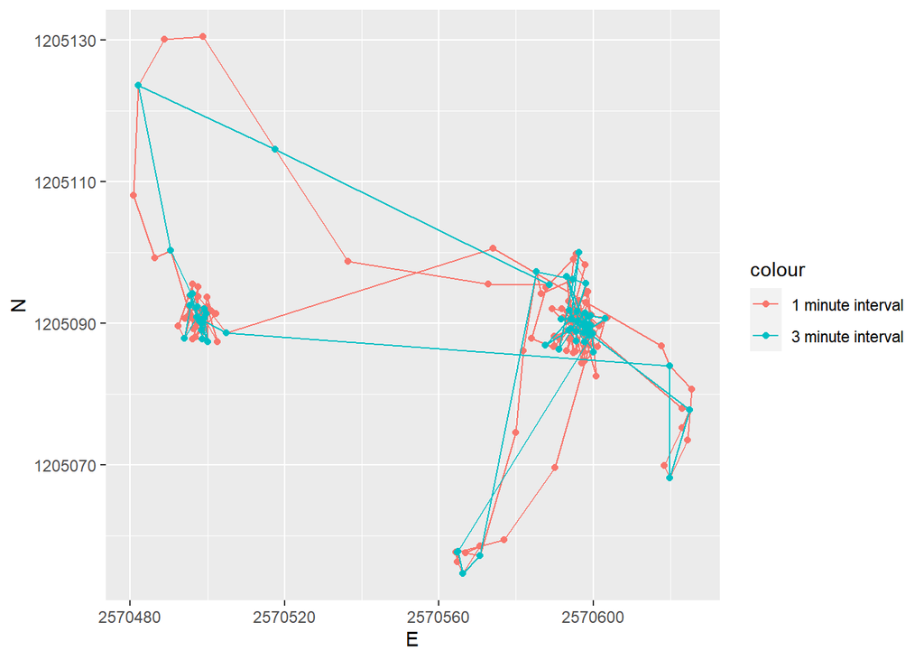

```r
ggplot() +
  geom_point(caro, mapping = aes(E, N, color = "1 minute interval")) +
  geom_path(caro, mapping = aes(E,N, color = "1 minute interval")) +
  geom_point(caro_3, mapping = aes(E, N, color = "3 minute interval")) +
  geom_path(caro_3, mapping = aes(E,N, color = "3 minute interval"))
```

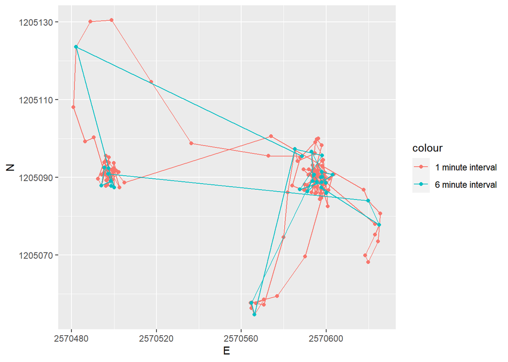

```r
ggplot() +
  geom_point(caro, mapping = aes(E, N, color = "1 minute interval")) +
  geom_path(caro, mapping = aes(E,N, color = "1 minute interval")) +
  geom_point(caro_6, mapping = aes(E, N, color = "6 minute interval")) +
  geom_path(caro_6, mapping = aes(E,N, color = "6 minute interval"))
```

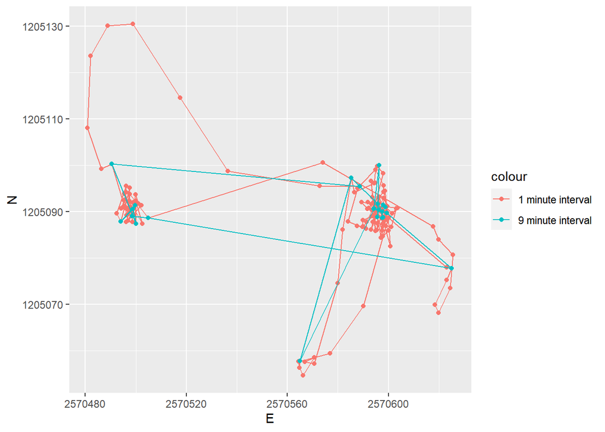

```r
ggplot() +
  geom_point(caro, mapping = aes(E, N, color = "1 minute interval")) +
  geom_path(caro, mapping = aes(E,N, color = "1 minute interval")) +
  geom_point(caro_9, mapping = aes(E, N, color = "9 minute interval")) +
  geom_path(caro_9, mapping = aes(E,N, color = "9 minute interval"))
```

Questions:

Intrepret the plots -> In the caro 3 and caro 6 the main trajectories are being preserved and even “simplified” as only the most important “staying points” of Caro remain. In the 9 minute intervals you start to lose some information like the upper part, so that interval would be to big for this data. In the first plot you see a gradual smoothing of the speed which comes naturally with the smoothing or “simplification” of the spatial pattern of the following trajectories.

# Task 5

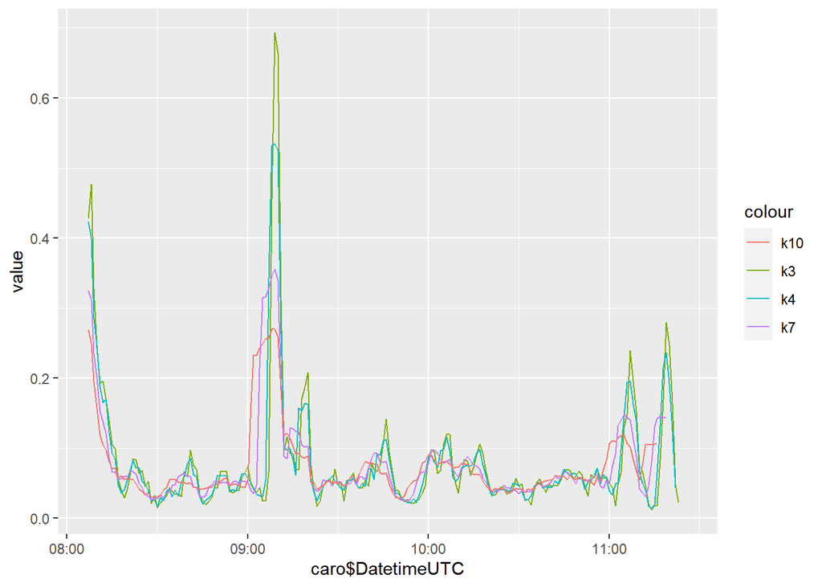

```r
caro_k3 <- rollmean(caro$speed, k = 3, fill = NA, align = "left") %>% as_data_frame()
caro_k4 <- rollmean(caro$speed, k = 4, fill = NA, align = "left") %>% as_data_frame()
caro_k7 <- rollmean(caro$speed, k = 7, fill = NA, align = "left") %>% as_data_frame()
caro_k10 <- rollmean(caro$speed, k = 10, fill = NA, align = "left") %>% as_data_frame()

colors_legend_rolling = c("k3" = "blue", "k4" = "red", "k7" = "green", "k10" = "yellow")
ggplot() +
  geom_line(caro_k3, mapping = aes(caro$DatetimeUTC, value, color = "k3")) +
  geom_line(caro_k4, mapping = aes(caro$DatetimeUTC, value, color = "k4")) +
  geom_line(caro_k7, mapping = aes(caro$DatetimeUTC, value, color = "k7")) +
  geom_line(caro_k10, mapping = aes(caro$DatetimeUTC, value, color = "k10"))
```